# Airbnb Paris data unsupervised clustering

jose lise

9/11/2019

The goal of this study is to cary out unsupervised clustering on Airbnb listing data in Paris. We will use hierarchical clustering and K-means plus PCA for the visualization.

## Loading data

```r
load('AirBnB-Paris-small.Rdata')
```

## Descriptive analysis

```r
summary(X)
```

```
##  host_listings_count host_total_listings_count
##  Min.   :  0.00      Min.   :  0.00
##  1st Qu.:  1.00      1st Qu.:  1.00
##  Median :  1.00      Median :  1.00
##  Mean   :  5.59      Mean   :  5.59
##  3rd Qu.:  2.00      3rd Qu.:  2.00
##  Max.   :629.00      Max.   :629.00
##  NA's   :10          NA's   :10
##                                                 host_verifications
##  ['email', 'phone', 'reviews', 'jumio']                  :3697
##  ['email', 'phone', 'reviews']                           :2827
##  ['email', 'phone']                                      : 787
##  ['email', 'phone', 'facebook', 'reviews', 'jumio']      : 736
##  ['email', 'phone', 'facebook', 'reviews']               : 459
##  ['email', 'phone', 'reviews', 'manual_offline', 'jumio']: 257
##  (Other)                                                 :1237
##  host_has_profile_pic host_identity_verified
##   :  10                :  10
##  f:  36               f:4869
##  t:9954               t:5121
##
##
##
##
##                                                                street
##  Paris, ÃŽle-de-France, France                                    :  69
##  Rue Oberkampf, Paris, ÃŽle-de-France 75011, France               :  50
##  Boulevard Voltaire, Paris, ÃŽle-de-France 75011, France          :  44
##  Rue du Faubourg Saint-Martin, Paris, ÃŽle-de-France 75010, France:  43
##  Rue de Charenton, Paris, ÃŽle-de-France 75012, France            :  39
##  Rue de Clignancourt, Paris, ÃŽle-de-France 75018, France         :  39
##  (Other)                                                          :9716
##                       neighbourhood          neighbourhood_cleansed
##                              :1397   Buttes-Montmartre  :1168
##  Montmartre                  : 547   Popincourt         : 917
##  RÃ©publique                 : 462   Vaugirard          : 749
##  Buttes-Chaumont - Belleville: 386   EntrepÃ´t          : 688
##  Batignolles                 : 355   Batignolles-Monceau: 677
##  XI Arrondissement           : 319   Passy              : 554
##  (Other)                     :6534   (Other)            :5247
```

[output cut: 137 more lines]

```
##  f:9667                           Min.   :  1.000
##  t: 333                           1st Qu.:  1.000
##                                   Median :  1.000
##                                   Mean   :  4.202
##                                   3rd Qu.:  1.000
##                                   Max.   :155.000
##
##  reviews_per_month
##  Min.   : 0.020
##  1st Qu.: 0.370
##  Median : 0.890
##  Mean   : 1.327
##  3rd Qu.: 1.830
##  Max.   :11.860
##  NA's   :2779
```

Keeping only apartments

```r
# filtering only apartments:
A <- X[X$property_type == 'Apartment',]
```

All the columns related to price display prices in character format, prefixed by “$” and with “,” for thousand delimiter. We will convert below those colums from characters to numeric using as.numeric and gsub functions.

```r
# Changing the price columns from character to numeric
A$price <- as.numeric(gsub('\\$|,', '', A$price))
A$weekly_price <- as.numeric(gsub('\\$|,', '', A$weekly_price))
A$monthly_price <- as.numeric(gsub('\\$|,', '', A$monthly_price))
A$security_deposit <- as.numeric(gsub('\\$|,', '', A$security_deposit))
A$cleaning_fee <- as.numeric(gsub('\\$|,', '', A$cleaning_fee))
A$extra_people <- as.numeric(gsub('\\$|,', '', A$extra_people))
```

In the section below, we will:  
* Drop columns with only missing values  
* For all numeric columns, replace missing value with median column value  
* double check that there is no remaining missing values

```r
# Checking missing values
#colSums(is.na(A))
#drop columns neighbourhood_group_cleansed and has_availability
# as they are empty
A$neighbourhood_group_cleansed <- NULL
A$has_availability <- NULL

# replace missing numerical values by the column median
nums <- unlist(lapply(A, is.numeric))
for (nm in names(nums)){
  #print(nm)
  #print(nums[[nm]])
  if ( nums[[nm]] ){
     myna <- is.na(A[[nm]])
     mycol <- A[[nm]]
     #mycol[myna] <- mean(A[[nm]],na.rm = TRUE)
     mycol[myna] <- median(A[[nm]],na.rm = TRUE)
     A[[nm]] <- mycol

  }
}

# double check that there is no missing values
colSums(is.na(A))
```

```
##              host_listings_count        host_total_listings_count
##                                0                                0
##               host_verifications             host_has_profile_pic
##                                0                                0
##           host_identity_verified                           street
##                                0                                0
##                    neighbourhood           neighbourhood_cleansed
##                                0                                0
##                             city                            state
##                                0                                0
##                          zipcode                           market
##                                0                                0
##                   smart_location                     country_code
##                                0                                0
##                          country                         latitude
##                                0                                0
##                        longitude                is_location_exact
##                                0                                0
##                    property_type                        room_type
##                                0                                0
##                     accommodates                        bathrooms
##                                0                                0
##                         bedrooms                             beds
##                                0                                0
##                         bed_type                        amenities
##                                0                                0
##                      square_feet                            price
##                                0                                0
##                     weekly_price                    monthly_price
##                                0                                0
##                 security_deposit                     cleaning_fee
##                                0                                0
##                  guests_included                     extra_people
##                                0                                0
##                   minimum_nights                   maximum_nights
##                                0                                0
##                 calendar_updated                  availability_30
##                                0                                0
##                  availability_60                  availability_90
##                                0                                0
##                 availability_365            calendar_last_scraped
##                                0                                0
##                number_of_reviews                     first_review
##                                0                                0
##                      last_review             review_scores_rating
##                                0                                0
##           review_scores_accuracy        review_scores_cleanliness
##                                0                                0
##            review_scores_checkin      review_scores_communication
##                                0                                0
##           review_scores_location              review_scores_value
##                                0                                0
##                 requires_license                          license
##                                0                                0
##               jurisdiction_names                 instant_bookable
##                                0                                0
##              cancellation_policy    require_guest_profile_picture
##                                0                                0
## require_guest_phone_verification   calculated_host_listings_count
##                                0                                0
##                reviews_per_month
##                                0
```

Check that there his no issue with the processed data by plotting an histogram of price variable.

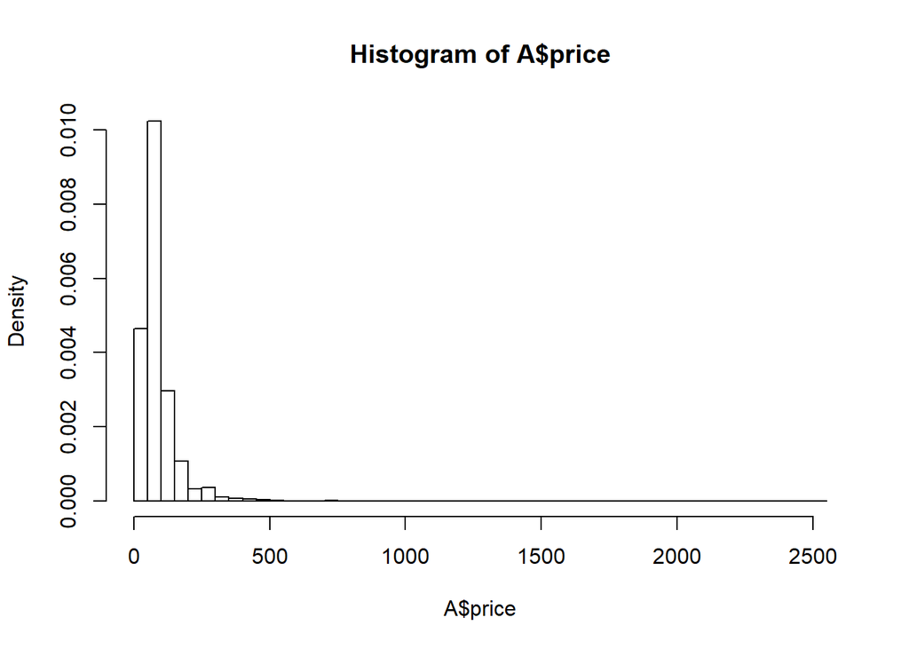

```r
hist(A$price, breaks = 50,freq=FALSE)
```

### Filter the features

We will only keep the numeric features

```r
nums <- unlist(lapply(A, is.numeric))
B <- A[,nums]
```

## Clustering

### Hierarchical clustering - Ward distance

Hierarchical clustering shows visually 5 main clusters.

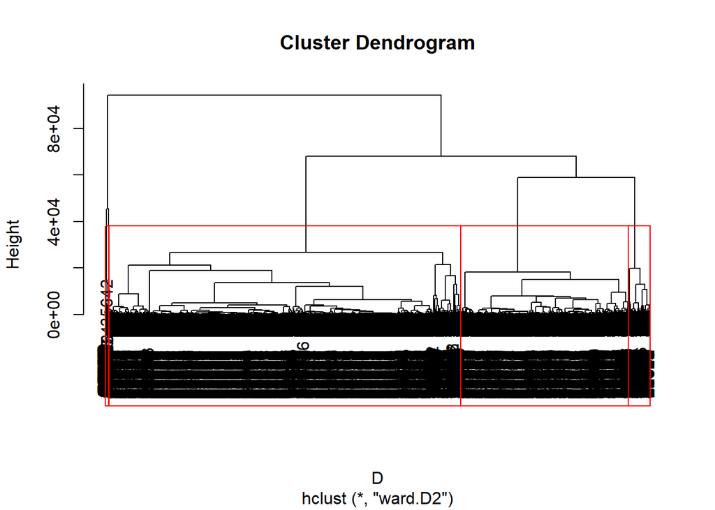

```r
D <- dist(B)
out <- hclust(D,method = "ward.D2")  # Using Ward distance
plot(out)

K1 = 5
res1 = cutree(out, K1)
rect.hclust(out,K1)
```

The visualization is not very good. We only see clearly the main 4 clusters.

We can also display the clustering using a map.

```r
#install.packages('leaflet')
library(leaflet)

palette = colorFactor("RdYlBu", domain = NULL)
leaflet(B) %>% addTiles() %>% addCircleMarkers(radius = 3, color =
     palette(res1),stroke = FALSE, fillOpacity = 0.9) %>%
  addLegend("bottomright", pal = palette, values = res1,
    title = "Clusters",
    opacity = 1
  )
```

```
## Assuming "longitude" and "latitude" are longitude and latitude, respectively
```

[interactive chart not shown]

```r
#palette(c(seq(K1))),stroke = FALSE, fillOpacity = 0.9)
#%>% addTiles() %>% addCircleMarkers(radius = 3, color = palette(out),stroke = FALSE, fillOpacity = 0.9)
```

We see that there is one big cluster (cluster 1) and other smaller clusters (2, 3). The clusters generally are not tied to a specific Paris location, except for the cluster 5 that is located on the 16th district.

Here is a picture of the rendering:

[figure not shown]

### Hierarchical clustering - other distances

- Single distance

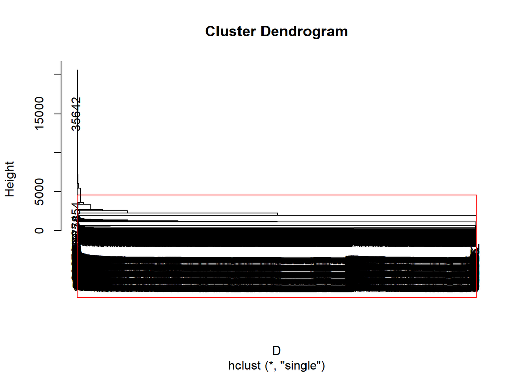

```r
#D <- dist(B)
out <- hclust(D,method = "single")  # Using single distance
plot(out)

K1 = 5
res1 = cutree(out, K1)
rect.hclust(out,K1)
```

We see basically a single cluster, the result is not good.

- Centroid distance

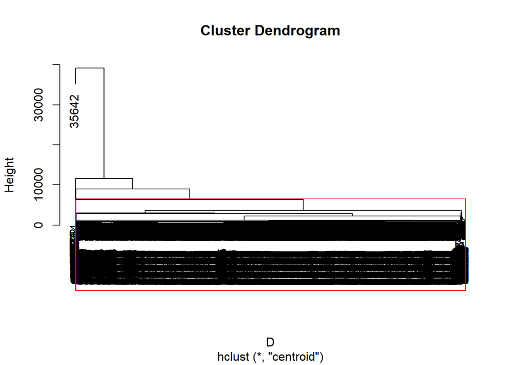

```r
out <- hclust(D,method = "centroid")  # Using centroid distance
plot(out)

K1 = 5
res1 = cutree(out, K1)
rect.hclust(out,K1)
```

Again, we see a single cluster, and we can confirm that the custering generated is not good.

- Complete distance

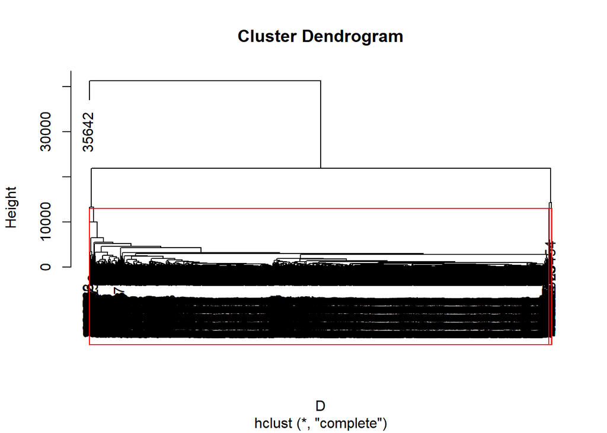

```r
out <- hclust(D,method = "complete")  # Using complete distance
plot(out)

K1 = 5
res1 = cutree(out, K1)
rect.hclust(out,K1)
```

Here we are able to identify 2 clusters, but it’s still a very unbalanced clustering.

### k-means clustering

We apply the k-mean clustering with 5 clusters as suggested by the hierarchical clustering.

```r
library(class)
set.seed(1234)
outk = kmeans(B,5, nstart= 15)
#outk
```

```r
palette = colorFactor("RdYlBu", domain = NULL)
leaflet(B) %>% addTiles() %>% addCircleMarkers(radius = 3, color =
     palette(outk$cluster),stroke = FALSE, fillOpacity = 0.9) %>%
  addLegend("bottomright", pal = palette, values = outk$cluster,
    title = "Clusters",
    opacity = 1
  )
```

```
## Assuming "longitude" and "latitude" are longitude and latitude, respectively
```

[interactive chart not shown]

[figure not shown]

Airbnb-Paris-KMeans

Next we will evaluate the best k for the k-means algorithm

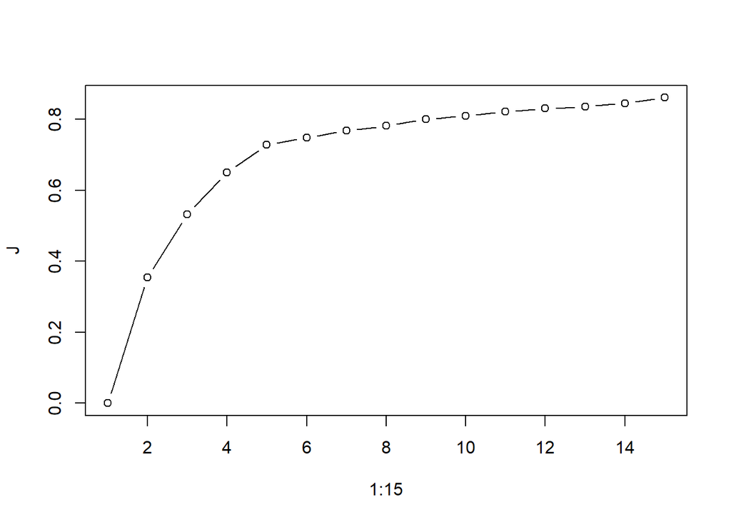

```r
J = c()
for (k in 1:15){
  out = kmeans(B,k,nstart=15)
  J[k] = out$betweenss / out$totss
}
plot(1:15,J,type='b')
```

We get the confirmation that the best k is k=5.

## Data visualization

We will use PCA to visualize the data and check dimensionality reduction.

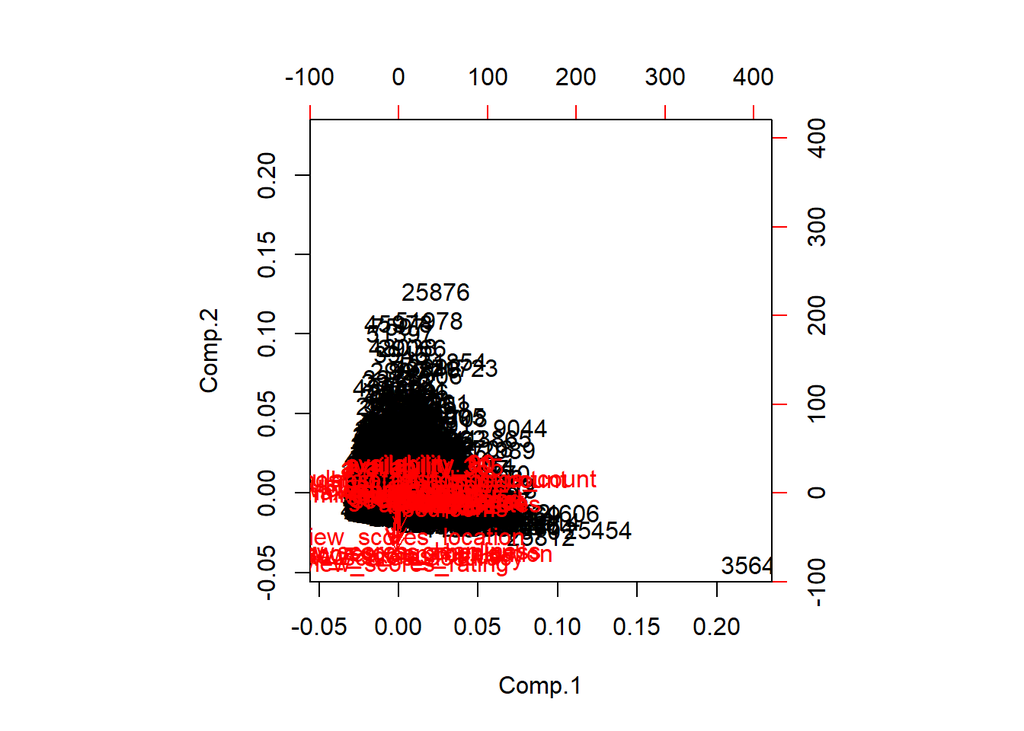

```r
out <- princomp(B,cor=TRUE)
#out = princomp(B)
Xproj <-  predict(out,B)
biplot(out)
```

```r
#summary(out)
```

Variance explained plot

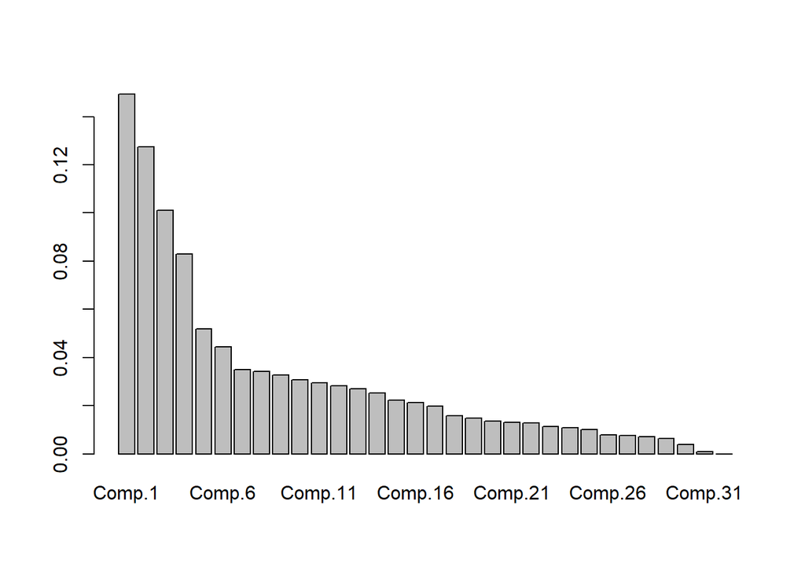

```r
var_explained <- out$sdev^2/sum(out$sdev^2)
barplot(var_explained)
```

Using the factoMiner Library

```r
library(FactoMineR)
out = PCA(B)
```

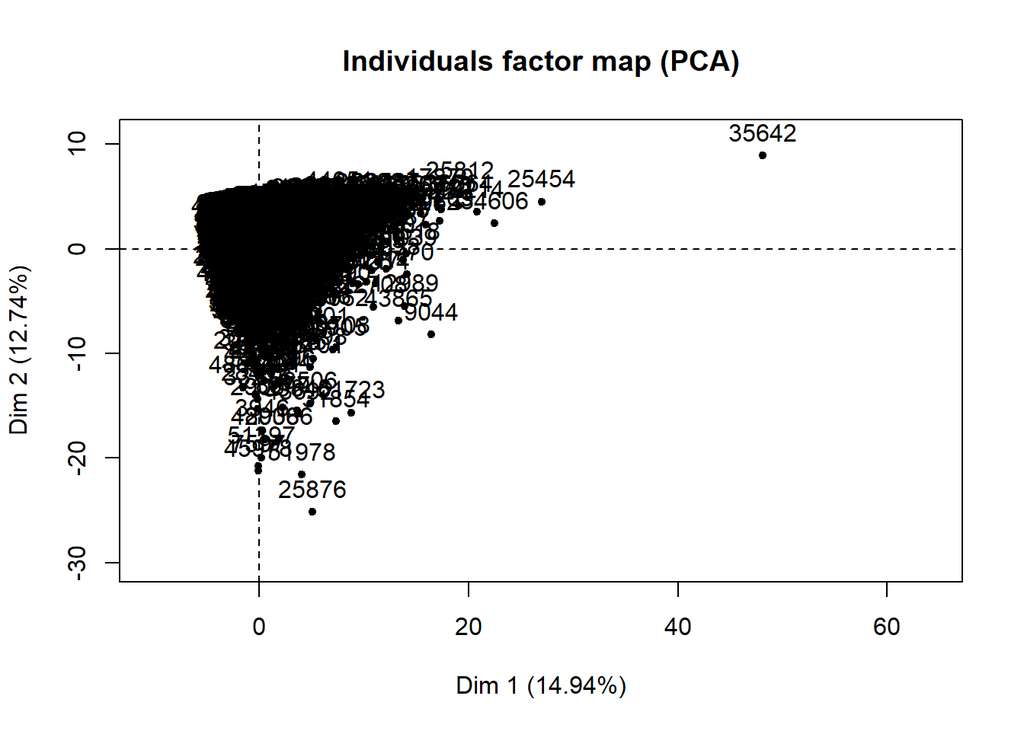

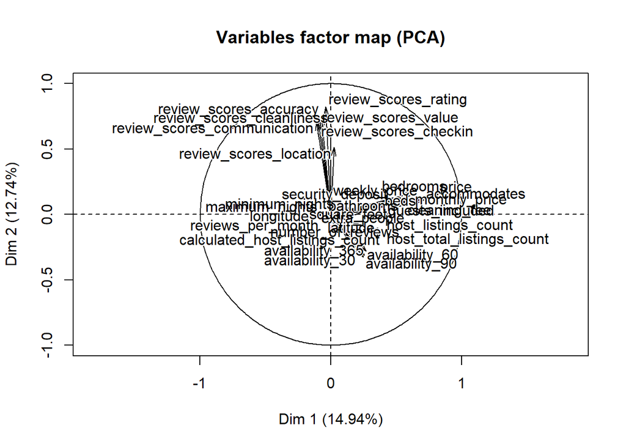

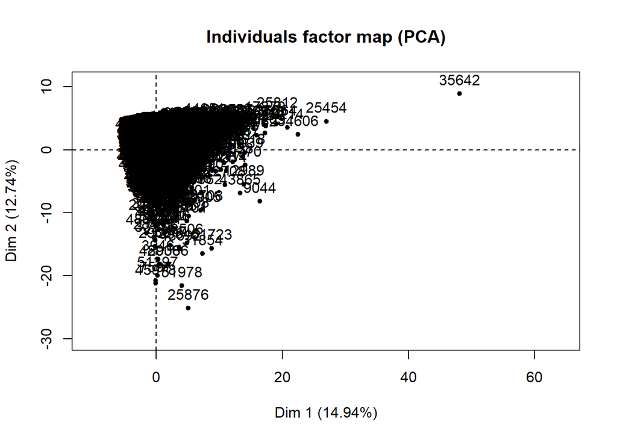

```r
plot(out)
```

Check the number of componenents to keep:

```r
out = princomp(B)
out$sdev
```

```
##       Comp.1       Comp.2       Comp.3       Comp.4       Comp.5
## 9.798342e+02 5.217788e+02 2.707822e+02 2.241843e+02 1.482172e+02
##       Comp.6       Comp.7       Comp.8       Comp.9      Comp.10
## 7.672523e+01 5.714860e+01 3.544248e+01 3.011991e+01 2.362143e+01
##      Comp.11      Comp.12      Comp.13      Comp.14      Comp.15
## 1.812170e+01 1.169195e+01 8.248311e+00 7.603147e+00 7.443734e+00
##      Comp.16      Comp.17      Comp.18      Comp.19      Comp.20
## 6.079727e+00 3.516055e+00 1.398590e+00 1.002998e+00 7.977740e-01
##      Comp.21      Comp.22      Comp.23      Comp.24      Comp.25
## 7.292336e-01 6.930943e-01 6.053322e-01 5.636759e-01 5.412645e-01
##      Comp.26      Comp.27      Comp.28      Comp.29      Comp.30
## 5.115612e-01 5.007334e-01 3.963225e-01 2.968166e-01 3.308140e-02
##      Comp.31      Comp.32
## 1.837764e-02 4.039403e-06
```

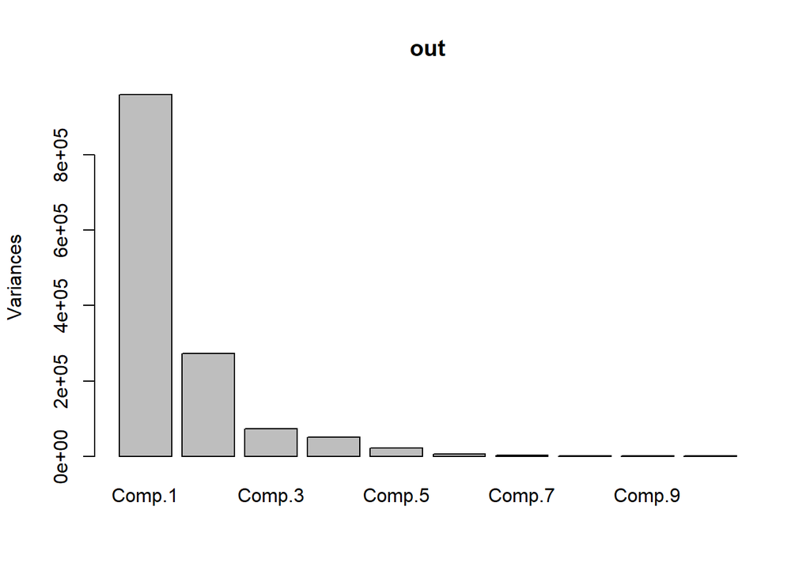

```r
plot(out)
```

```r
summary(out)
```

```
## Importance of components:
##                             Comp.1      Comp.2       Comp.3       Comp.4
## Standard deviation     979.8341986 521.7788447 270.78215551 224.18430784
## Proportion of Variance   0.6904758   0.1958016   0.05273311   0.03614546
## Cumulative Proportion    0.6904758   0.8862774   0.93901056   0.97515602
##                              Comp.5       Comp.6       Comp.7       Comp.8
## Standard deviation     148.21716778 76.725225700 57.148595336 3.544248e+01
## Proportion of Variance   0.01579939  0.004233696  0.002348845 9.034237e-04
## Cumulative Proportion    0.99095541  0.995189101  0.997537947 9.984414e-01
##                              Comp.9      Comp.10      Comp.11      Comp.12
## Standard deviation     3.011991e+01 2.362143e+01 18.121703411 1.169195e+01
## Proportion of Variance 6.524552e-04 4.012877e-04  0.000236179 9.831440e-05
## Cumulative Proportion  9.990938e-01 9.994951e-01  0.999731292 9.998296e-01
##                             Comp.13      Comp.14      Comp.15      Comp.16
## Standard deviation     8.248311e+00 7.603147e+00 7.4437344790 6.079727e+00
## Proportion of Variance 4.892979e-05 4.157479e-05 0.0000398497 2.658346e-05
## Cumulative Proportion  9.998785e-01 9.999201e-01 0.9999599609 9.999865e-01
##                             Comp.17      Comp.18      Comp.19      Comp.20
## Standard deviation     3.516055e+00 1.398590e+00 1.002998e+00 7.977740e-01
## Proportion of Variance 8.891082e-06 1.406774e-06 7.235087e-07 4.577233e-07
## Cumulative Proportion  9.999954e-01 9.999968e-01 9.999976e-01 9.999980e-01
##                             Comp.21      Comp.22      Comp.23      Comp.24
## Standard deviation     7.292336e-01 6.930943e-01 6.053322e-01 5.636759e-01
## Proportion of Variance 3.824518e-07 3.454840e-07 2.635305e-07 2.285085e-07
## Cumulative Proportion  9.999984e-01 9.999988e-01 9.999990e-01 9.999992e-01
##                             Comp.25      Comp.26      Comp.27      Comp.28
## Standard deviation     5.412645e-01 5.115612e-01 5.007334e-01 3.963225e-01
## Proportion of Variance 2.106990e-07 1.882082e-07 1.803252e-07 1.129642e-07
## Cumulative Proportion  9.999995e-01 9.999996e-01 9.999998e-01 9.999999e-01
##                             Comp.29      Comp.30      Comp.31      Comp.32
## Standard deviation     2.968166e-01 3.308140e-02 1.837764e-02 4.039403e-06
## Proportion of Variance 6.336066e-08 7.870656e-10 2.428975e-10 1.173485e-17
## Cumulative Proportion  1.000000e+00 1.000000e+00 1.000000e+00 1.000000e+00
```

The cattell’s test:

```r
myPCA <- function(X,d=2){
  # Covariance estimation
  Xbar = scale(X,center=TRUE,scale=FALSE)
  Sigma = 1/nrow(Xbar) * t(Xbar) %*% Xbar

  # Eigen-decomposition
  out = eigen(Sigma)

  # Return the PC axes and plot the projection
  U = out$vectors[,1:d]
  Xproj = as.matrix(X) %*% U
#  if (d <= 2) plot(Xproj,type='p',pch=19)
#  else pairs(Xproj,pch=19)
  return(list(U=U,lambda=out$values))
}
```

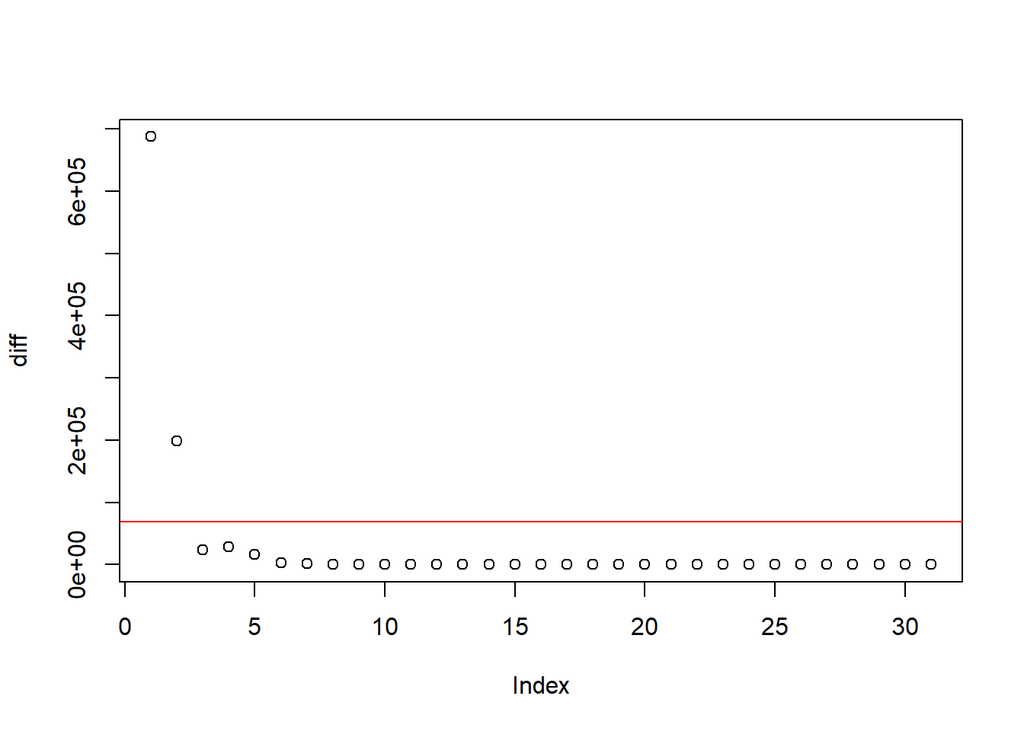

```r
out = myPCA(B)
diff = abs(diff(out$lambda))
plot(diff)
abline(h=0.1*max(diff),col='red')
```

### Retry the K-Means algorithm

```r
set.seed(1234)
outk = kmeans(B,5, nstart= 15)
#outk
```

```r
palette = colorFactor("RdYlBu", domain = NULL)
leaflet(B) %>% addTiles() %>% addCircleMarkers(radius = 3, color =
     palette(outk$cluster),stroke = FALSE, fillOpacity = 0.9) %>%
  addLegend("bottomright", pal = palette, values = outk$cluster,
    title = "Clusters",
    opacity = 1
  )
```

```
## Assuming "longitude" and "latitude" are longitude and latitude, respectively
```

[interactive chart not shown]

[figure not shown]

Airbnb-Paris-KMeans-Final